# House Price Prediction in Boulder, CO

Xiaoyi Wu

10/20/2021

# **01. Introduction & Motivation**

## 1.1 Brief introduction of Boulder County

As one of the most popular real estate websites in the United States, Zillow and its affiliates offer customers an on-demand experience for selling, buying, renting and financing with transparency and nearly seamless end-to-end service. These years, Zillow has produced home value reports for the U.S. and over 130 metropolitan statistical areas. The reports identify market trends including, but not limited to: 5- and 10-year annualized change, negative equity, short sales and foreclosure transactions.

However, Zillow has realized that its housing market predictions are not as accurate as they would like. Thus, here, we build a regression model to help Zillow predict the sale price of housing in Boulder County, Colorado between 2019 and 2021.

Here are several main characteristics of the Boulder County housing market:

**1. Close proximity to Denver**: The Boulder real estate market has all the earmarks of being sustainable. It has benefited a lot from its close proximity to Denver and the employment rate of Boulder County is well above the national average.

**2. Abundant landscape features from farmland to rolling grasslands in the plains**: Boulder County is close to Rocky Mountains. U.S. Route 36 from Denver with its iconic sandstone slabs rising from the mountains, prefaced by pine-clad mesas and cradled within the backdrop of the snow-capped Indian Peaks provide around 2000 miles of hiking trials and massive green space to Boulder County.

**3. Livable metro areas**: In the metro area, there are roughly 300,000 people. The district has seen growth as people move from the expensive, over-crowded Denver area to Boulder County where you can still hike in the mountains and see the hills. Boulder County ranks second in Best Places to live for quality of life in U.S. News.

Therefore, considering the characteristics mentioned above, we adopt a geospatial machine learning model to incorporate natural resources distribution and neighborhood effects with socio-economic factors to predict the house prices in various areas of the county.

# **02.Data Exploration**

## 2.1 Datsets

- **01. The Boulder County Assessor Public Dataset**: We collect data related to internal and physical house condition from this dataset.

```r
d <- cbind(Variable =c('qualityCode','builtYear','EffectiveYear','bsmtSF','carStorageSF','nbrBedRoom','nbrRoomsNobath','mainfloorSF','nbrFullBaths','bathnum'),
           Description = c('house quality','Year in which the building began construction','The effective year built','Square footage of the basement type','carStorageSF','Number of bedrooms','Total number of rooms excluding bathrooms','Total finished square footage of the main floor','Number of full bathrooms','Number of bathrooms'))

kable(d, caption="Physical features",
        digits=2) %>%
  kable_styling() %>%
  scroll_box(width = "100%", height = "300px")
```

Physical features

| Variable | Description |
| --- | --- |
| qualityCode | house quality |
| builtYear | Year in which the building began construction |
| EffectiveYear | The effective year built |
| bsmtSF | Square footage of the basement type |
| carStorageSF | carStorageSF |
| nbrBedRoom | Number of bedrooms |
| nbrRoomsNobath | Total number of rooms excluding bathrooms |
| mainfloorSF | Total finished square footage of the main floor |
| nbrFullBaths | Number of full bathrooms |
| bathnum | Number of bathrooms |

- **02.Boulder Base Data**: We collect boundary of Boulder county from this dataset.
- **03.Census tract and some neighborhood units of Boulder County**: As an alternative to using neighborhood data of the entire county, we collect the geometric data from the census tract of Boulder county in 2019.
- **04. American Community Survey (ACS)**: We collect demographic information from the 5-year American Community Survey census data.

```r
d <- cbind(Variable =c('TotalPop','Whites','MedHHInc','MedRent','TotalPoverty','FemaleBachelors'),
           Description = c('Total population in each census tract','White population in each census tract','Median household income in each census tract','Median Rent for properties in each census tract','Population living under the level of poverty in each census tract','Female population whose degree is bachelor or higher'))

kable(d, caption="Demographyic features",
        digits=2) %>%
  kable_styling() %>%
  scroll_box(width = "100%", height = "300px")
```

Demographyic features

| Variable | Description |
| --- | --- |
| TotalPop | Total population in each census tract |
| Whites | White population in each census tract |
| MedHHInc | Median household income in each census tract |
| MedRent | Median Rent for properties in each census tract |
| TotalPoverty | Population living under the level of poverty in each census tract |
| FemaleBachelors | Female population whose degree is bachelor or higher |

- **05.OpenStreetMap and the Boulder County Open Data Portal**: We collect the amenity and public service data including health care service, entertainment accessibility, natural resources, open space, education opportunity in Boulder county from these datasets.

```r
d <- cbind(Variable =c('CDPHE Health Facilities','Transit system','Open space','Libraries','School','Resturant','Theater'),
           Description = c('Addresses represented as point locations for regulated CDPHE health facilities','Area of trails and traffic stations','Open spaces in the county','Public libraries','School point data','Restaurant point data','Theater point data'))

kable(d, caption="Amenity/public service features",
        digits=2) %>%
  kable_styling() %>%
  scroll_box(width = "100%", height = "300px")
```

Amenity/public service features

| Variable | Description |
| --- | --- |
| CDPHE Health Facilities | Addresses represented as point locations for regulated CDPHE health facilities |
| Transit system | Area of trails and traffic stations |
| Open space | Open spaces in the county |
| Libraries | Public libraries |
| School | School point data |
| Resturant | Restaurant point data |
| Theater | Theater point data |

```r
setwd("D:\\MUSA\\fall\\MUSA508\\handover")


boulder.s <- st_read('.\\data\\studentData.geojson',crs='ESRI:102254')


boulder.sf <-
  boulder.s %>%
 # st_as_sf(coords = c("Longitude", "Latitude"), crs = 'ESRI:102254', agr = "constant") %>%
  #st_transform('ESRI:102254') %>%
    mutate(bathnum=nbrThreeQtrBaths+nbrFullBaths
         +nbrHalfBaths)
boulder.boundary <-
  st_read("https://opendata.arcgis.com/datasets/964b8f3b3dbe401bb28d49ac93d29dc4_0.geojson") %>%
  st_transform(st_crs(boulder.sf))

Health_Facilities <-
  st_read('data/CDPHE_Health_Facilities.geojson')%>%
 st_transform(st_crs(boulder.sf))

   #Select health facilities which locate within Boulder County border.
Health_Facilities <- st_join(Health_Facilities, boulder.boundary,
                             join = st_intersects, left = FALSE)


Health_facility.sf <- Health_Facilities%>%
  select(geometry)%>%
  na.omit()%>%
  distinct()


##02.transit systems
#02.1Boulder Area Trails：Consolidated regional trails for the regional trails application.
Area_Trails <-
  st_read('data/Boulder_Area_Trails.geojson')%>%
  st_transform(st_crs(boulder.sf))

Area_Trails <- st_join(Area_Trails, boulder.boundary,
                             join = st_intersects, left = FALSE)

Area_Trails.sf <- Area_Trails%>%
  select(geometry)%>%
  na.omit()%>%
  distinct()

#02.2 Boulder traffic stations.
Traffic_stations <-
  st_read('data/Traffic_Stations.geojson')%>%
  st_transform(st_crs(boulder.sf))

Traffic_stations <- st_join(Traffic_stations, boulder.boundary,
                             join = st_intersects, left = FALSE)

Traffic_stations.sf <- Traffic_stations%>%
  select(geometry)%>%
  na.omit()%>%
  distinct()

#03.open space
Openspace <-
  st_read('data/County_Open_Space.geojson')%>%
  st_transform(st_crs(boulder.sf))

#Select open spaces which locate within Boulder County border.
Openspace <- st_join(Openspace, boulder.boundary,
                             join = st_intersects, left = FALSE)


#clean openspace
Openspace.sf <-
  Openspace %>%
  select(geometry)%>%
    na.omit() %>%
    st_transform(st_crs(boulder.sf))  %>%
    distinct()

#04.libraries
Libraries <-
  st_read('data/Libraries.geojson')

#clean libraries
Libraries.sf <-
  Libraries %>%
  select(geometry)%>%
    na.omit() %>%
    st_as_sf(coords = c("geometry"), crs = 4326, agr = "constant") %>%
    st_transform(st_crs(boulder.sf))  %>%
    distinct()

#05.Landmark
landmark01 <- st_read('data/landmark01.geojson')%>%
 st_transform(st_crs(boulder.sf))

landmark02 <- st_read('data/landmark02.geojson')%>%
 st_transform(st_crs(boulder.sf))

landmark <- st_join(landmark01,landmark02,join = st_intersects, left = TRUE)%>%
  select(geometry)%>%
  na.omit() %>%
  distinct()

#06.school
school <-
  st_read('data/school.csv') %>%

  mutate(x = gsub("[c()]", "",geometry)) %>%
    separate(x,into= c("Y","X"), sep=",") %>%
    mutate(X = as.numeric(X),Y = as.numeric(Y)) %>%
    drop_na(X) %>%
    st_as_sf(coords = c("Y", "X"), crs = 4326)%>%
  st_transform('ESRI:102254')

#clean school data
school.sf<-school%>%
 select(geometry)%>%
  na.omit()%>%
  distinct()

#mapview::mapview(school.sf)

#07.restaurant
restaurant <-
st_read('data/restaurant.csv') %>%
  mutate(x = gsub("[c()]", "",geometry)) %>%
    separate(x,into= c("Y","X"), sep=" ") %>%
    mutate(X = as.numeric(X),Y = as.numeric(Y)) %>%
    drop_na(X) %>%
    st_as_sf(coords = c("Y", "X"), crs = 4326)%>%
  st_transform('ESRI:102254')

#clean restaurant
restaurant.sf <- restaurant%>%
  select(geometry)%>%
  na.omit()%>%
  distinct()
#mapview::mapview(restaurant.sf)


#08.theater
theater <-
st_read('data/theater.csv') %>%
  mutate(x = gsub("[c()]", "",geometry)) %>%
    separate(x,into= c("Y","X"), sep=" ") %>%
    mutate(X = as.numeric(X),Y = as.numeric(Y)) %>%
    drop_na(X) %>%
    st_as_sf(coords = c("Y", "X"), crs = 4326)%>%
  st_transform('ESRI:102254')

#clean theater
theater.sf <- theater%>%
  select(geometry)%>%
  na.omit()%>%
  distinct()
census_api_key("9e5876bd913ec7705eb4b93ee17937abb9bf8d2b")

tracts2019 <- get_acs(geography = "tract", variables = c("B25026_001E","B02001_002E",
                                             "B19013_001E","B25058_001E",
                                             "B06012_002E",
                                             # vacant variables
                                             "B25002_003E",
                                             "B25004_002E","B25004_003E",
                                             "B25004_004E","B25004_005E",
                                             # total housing unit
                                             "B25001_001E",
                                             # renter occupied
                                             'B08137_003E'),
          year=2019, state= 08, county= 013, geometry=T, output="wide") %>%
  st_transform(st_crs(boulder.sf)) %>%
  rename(TotalPop = B25026_001E,
         Whites = B02001_002E,
         MedHHInc = B19013_001E,
         MedRent = B25058_001E,
         TotalPoverty = B06012_002E,
         TotalVacant = B25002_003E,
         ForRent = B25004_002E,
         ForRentVac = B25004_003E,
         ForSale = B25004_004E,
         ForSaleVac = B25004_005E,
         TotalUnit = B25001_001E,
         RenterOccupied = B08137_003E
         ) %>%
  dplyr::select(-NAME, -starts_with("B")) %>%
  mutate(pctWhite = ifelse(TotalPop > 0, Whites / TotalPop,0),
         pctPoverty = ifelse(TotalPop > 0, TotalPoverty / TotalPop, 0),
         pctTotalVacant = ifelse(TotalUnit > 0, TotalVacant / TotalUnit * 100, 0),
         TotalOccupied = TotalUnit - TotalVacant,
        pctRenterOccupied = ifelse(TotalOccupied >0, RenterOccupied/TotalOccupied, 0)) %>%
  dplyr::select(-Whites, -TotalPoverty)

projected.tracts2019 <-
    tracts2019 %>%
 st_transform(st_crs(boulder.sf))
```

### 2.2 Feature engineering

```r
st_c <- st_coordinates

boulder.sf <-
  boulder.sf %>%
    mutate(
      health_nn1 = nn_function(st_c(boulder.s), st_c(Health_facility.sf), 1),
      health_nn2 = nn_function(st_c(boulder.s), st_c(Health_facility.sf), 2),
      health_nn3 = nn_function(st_c(boulder.s), st_c(Health_facility.sf), 3),
      health_nn4 = nn_function(st_c(boulder.s), st_c(Health_facility.sf), 4),
      health_nn5 = nn_function(st_c(boulder.s), st_c(Health_facility.sf), 5))


boulder.sf <-
  boulder.sf %>%
    mutate(
      library_nn1 = nn_function(st_c(boulder.sf), st_c(Libraries.sf), 1),
      library_nn2 = nn_function(st_c(boulder.sf), st_c(Libraries.sf), 2),
      library_nn3 = nn_function(st_c(boulder.sf), st_c(Libraries.sf), 3))


boulder.sf <-
  boulder.sf %>%
    mutate(
      Tra_station_nn1 = nn_function(st_c(boulder.sf), st_c(st_centroid(Traffic_stations.sf)), 1),
      Tra_station_nn2 = nn_function(st_c(boulder.sf), st_c(st_centroid(Traffic_stations.sf)), 2),
      Tra_station_nn3 = nn_function(st_c(boulder.sf), st_c(st_centroid(Traffic_stations.sf)), 3),
      Tra_station_nn4 = nn_function(st_c(boulder.sf), st_c(st_centroid(Traffic_stations.sf)), 4),
      Tra_station_nn5 = nn_function(st_c(boulder.sf), st_c(st_centroid(Traffic_stations.sf)), 5))

boulder.sf <-
  boulder.sf %>%
    mutate(
      Openspace_nn1 = nn_function(st_c(boulder.sf), st_c(st_centroid(Openspace.sf)), 1),
      Openspace_nn2 = nn_function(st_c(boulder.sf), st_c(st_centroid(Openspace.sf)), 2),
      Openspace_nn3 = nn_function(st_c(boulder.sf), st_c(st_centroid(Openspace.sf)), 3),
      Openspace_nn4 = nn_function(st_c(boulder.sf), st_c(st_centroid(Openspace.sf)), 4),
      Openspace_nn5 = nn_function(st_c(boulder.sf), st_c(st_centroid(Openspace.sf)), 5))


boulder.sf <-
  boulder.sf %>%
    mutate(
      Area_Trail_nn1 = nn_function(st_c(boulder.sf), st_c(st_centroid(Area_Trails.sf)), 1),
      Area_Trail_nn2 = nn_function(st_c(boulder.sf), st_c(st_centroid(Area_Trails.sf)), 2),
      Area_Trail_nn3 = nn_function(st_c(boulder.sf), st_c(st_centroid(Area_Trails.sf)), 3),
      Area_Trail_nn4 = nn_function(st_c(boulder.sf), st_c(st_centroid(Area_Trails.sf)), 4),
      Area_Trail_nn5 = nn_function(st_c(boulder.sf), st_c(st_centroid(Area_Trails.sf)), 5))

boulder.sf <-
  boulder.sf %>%
    mutate(
      landmark_nn1 = nn_function(st_c(boulder.sf), st_c(st_centroid(landmark)), 1),
      landmark_nn2 = nn_function(st_c(boulder.sf), st_c(st_centroid(landmark)), 2),
      landmark_nn3 = nn_function(st_c(boulder.sf), st_c(st_centroid(landmark)), 3),
      landmark_nn4 = nn_function(st_c(boulder.sf), st_c(st_centroid(landmark)), 4),
      landmark_nn5 = nn_function(st_c(boulder.sf), st_c(st_centroid(landmark)), 5))


boulder.sf <-
  boulder.sf %>%
    mutate(
      school_nn1 = nn_function(st_c(boulder.sf), st_c(school.sf), 1),
      school_nn2 = nn_function(st_c(boulder.sf), st_c(school.sf), 2),
      school_nn3 = nn_function(st_c(boulder.sf), st_c(school.sf), 3),
      school_nn4 = nn_function(st_c(boulder.sf), st_c(school.sf), 4),
      school_nn5 = nn_function(st_c(boulder.sf), st_c(school.sf), 5))


boulder.sf <-
  boulder.sf %>%
    mutate(
      theater_nn1 = nn_function(st_c(boulder.sf), st_c(theater.sf), 1),
      theater_nn2 = nn_function(st_c(boulder.sf), st_c(theater.sf), 2),
      theater_nn3 = nn_function(st_c(boulder.sf), st_c(theater.sf), 3),
      theater_nn4 = nn_function(st_c(boulder.sf), st_c(theater.sf), 4),
      theater_nn5 = nn_function(st_c(boulder.sf), st_c(theater.sf), 5))

boulder.sf <-
  boulder.sf %>%
    mutate(
      restaurant_nn1 = nn_function(st_c(boulder.sf), st_c(restaurant.sf), 1),
      restaurant_nn2 = nn_function(st_c(boulder.sf), st_c(restaurant.sf), 2),
      restaurant_nn3 = nn_function(st_c(boulder.sf), st_c(restaurant.sf), 3),
      restaurant_nn4 = nn_function(st_c(boulder.sf), st_c(restaurant.sf), 4),
      restaurant_nn5 = nn_function(st_c(boulder.sf), st_c(restaurant.sf), 5))

index <- boulder.sf %>%
  rowid_to_column(var = "rowIndex")

boulder.sf <-st_join(index, projected.tracts2019) %>%
  distinct(rowIndex, .keep_all = TRUE)

nhoods<-projected.tracts2019%>%
  dplyr::select(GEOID,geometry)

index.neigh <-st_join(index,nhoods) %>%
  distinct(rowIndex, .keep_all = TRUE)


train_data<- filter(boulder.sf,toPredict==0)
test_data<- filter(boulder.sf,toPredict==1)
```

```r
#write.csv(x = train_data,file = "train_data.csv")

all.feature.list <- boulder.sf %>%
   dplyr:: select(
  -Ac,-AcDscr,-address,-bld_num,-bldgClass,-bldgClassDscr,-bsmtType,-bsmtTypeDscr,-carStorageType,
    -carStorageTypeDscr,-CompCode,-ConstCode,-ConstCodeDscr,-designCodeDscr,-starts_with("ExtWall"),-Heating,-HeatingDscr,-IntWall,-IntWallDscr,-nbrHalfBaths,-qualityCodeDscr,-Roof_Cover,-Roof_CoverDscr,-saleDate,-section_num,-status_cd,-Stories,-UnitCount,-year,-year_quarter
)%>%
st_drop_geometry()
internal.feature.list <- all.feature.list %>%
   dplyr::select(builtYear,bsmtSF,carStorageSF,nbrRoomsNobath,nbrThreeQtrBaths,nbrFullBaths,
                  qualityCode,EffectiveYear,nbrBedRoom,mainfloorSF,designCode)

amenity_feature.list <- all.feature.list %>%
  dplyr:: select(
    starts_with('health_'),starts_with('landmark_'),starts_with('Openspace'),starts_with('Area_Trail'),starts_with('Tra_station'),starts_with('restaurant'),starts_with('theater'),starts_with('school'),starts_with('library_'))

census.feature.list <- all.feature.list %>%
  dplyr:: select(pctRenterOccupied,pctTotalVacant,pctWhite,TotalUnit,MedHHInc)

spatial.feature.list <- all.feature.list %>%
  dplyr:: select(GEOID)
```

## 2.3 Correlation matrix

### 2.3.1 All features

From the correlation matrix below, dark blue indicates two features are strongly and positively correlated with each other, while dark green indicates a strongly negative correlation. White means there is no correlation between the features.

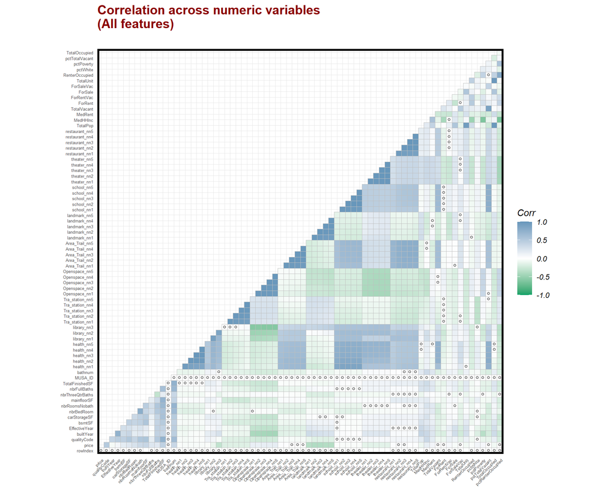

```r
numericVars.all<-
  select_if(all.feature.list,is.numeric)%>%
  na.omit()

ggcorrplot(
  round(cor(numericVars.all), 2),
  p.mat = cor_pmat(numericVars.all),
  colors = c('#05A167', "white", '#6897BB'),
  lab_size = 1,
  tl.cex = 5,
  type="lower",
  insig = c("pch", "blank"), pch = 1, pch.col = "black", pch.cex =1) +
  labs(title = "Correlation across numeric variables\n(All features)\n") +
  plotTheme()
```

### 2.3.2 Amenity feature

From the correlation matrix below, we can clearly see that the theater distribution has negative correlation with the open space. And the school’s location is highly and positively correlated with health care’s location.

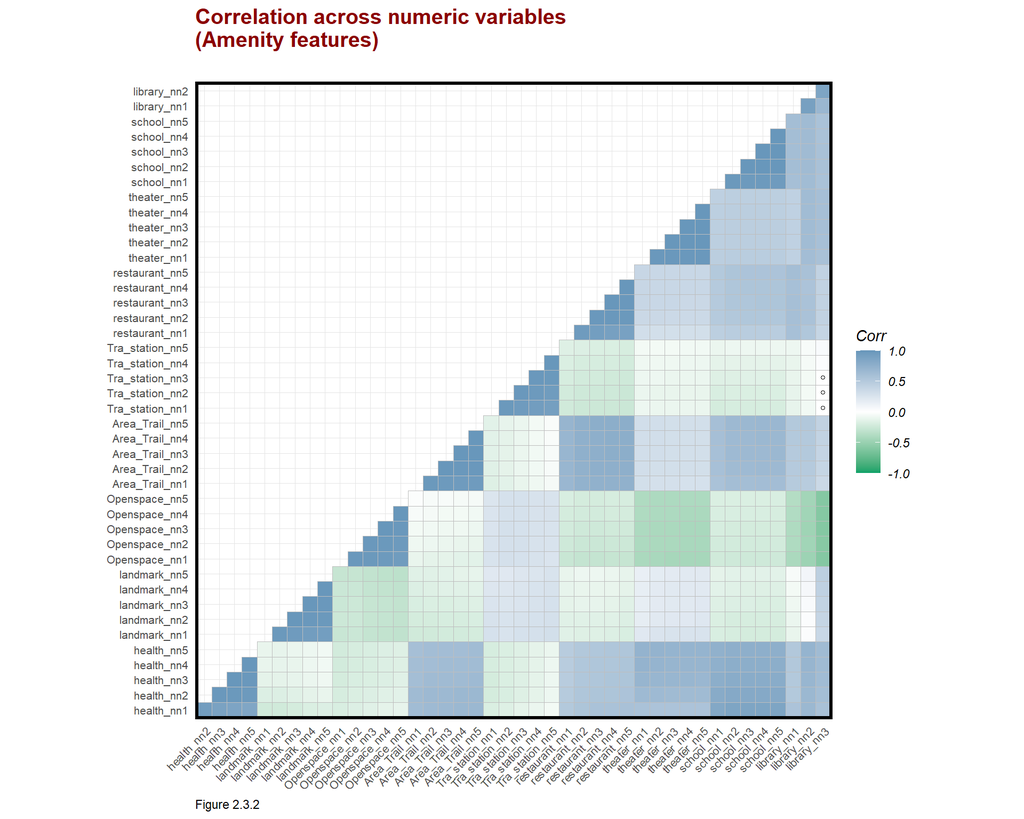

```r
numericVars.Amenity<-
  select_if(amenity_feature.list,is.numeric)%>%
  na.omit()

ggcorrplot(
  round(cor(numericVars.Amenity), 2),
  p.mat = cor_pmat(numericVars.Amenity),
  colors = c('#05A167', "white", '#6897BB'),
  lab_size = 1,
  tl.cex = 8,
  type="lower",
  insig = c("pch", "blank"), pch = 1, pch.col = "black", pch.cex =1) +
  labs(title = "Correlation across numeric variables\n(Amenity features)\n",
       caption = 'Figure 2.3.2') +
  plotTheme()
```

### 2.3.3 Internal feature From the correlation matrix below, we can clearly see that the built year has highly positive correlation with the effective year. And the number of 3/4 bathroom is negatively correlated with full bathroom number.

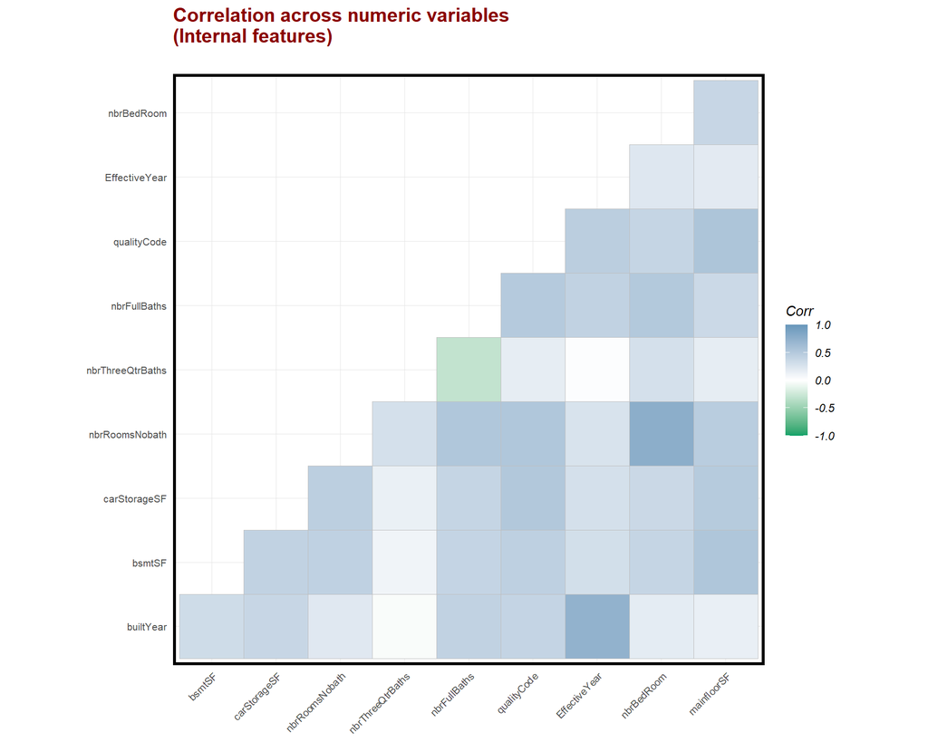

```r
numericVars.Internal<-
  select_if(internal.feature.list,is.numeric)%>%
  na.omit()

ggcorrplot(
  round(cor(numericVars.Internal), 2),
  p.mat = cor_pmat(numericVars.Internal),
  colors = c('#05A167', "white", '#6897BB'),
  lab_size = 1,
  tl.cex = 8,
  type="lower",
  insig = c("pch", "blank"), pch = 1, pch.col = "black", pch.cex =1) +
  labs(title = "Correlation across numeric variables\n(Internal features)\n") +
  plotTheme()
```

### 2.3.4 Demographic feature

From the matrix of census features below, we can see that the medium house income and the percent of houses occupied by renters have strongly negative correlation. It indicates the higher the renter occupation rate is, the less income the households will get.

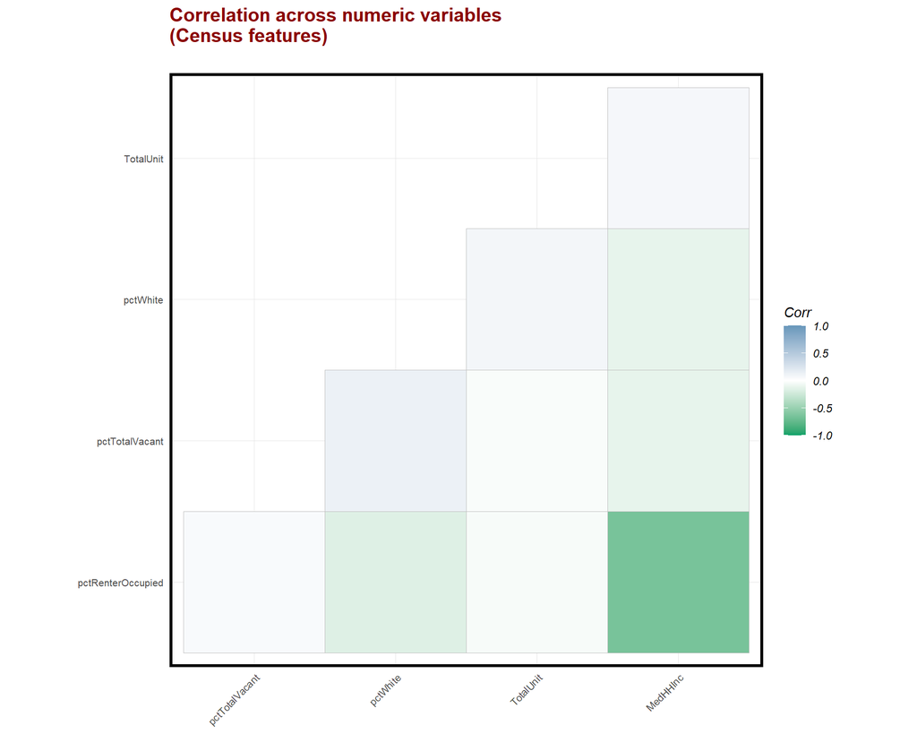

```r
numericVars.Census<-
  select_if(census.feature.list,is.numeric)%>%
  na.omit()

ggcorrplot(
  round(cor(numericVars.Census), 2),
  p.mat = cor_pmat(numericVars.Census),
  colors = c('#05A167', "white", '#6897BB'),
  lab_size = 1,
  tl.cex = 8,
  type="lower",
  insig = c("pch", "blank"), pch = 1, pch.col = "black", pch.cex =1) +
  labs(title = "Correlation across numeric variables\n(Census features)\n") +
  plotTheme()
```

### 2.3.5 Home price as a function of four numeric features

For the plots below, We choose “percentage of white people”,“number of bedroom”,“the quality code”,“number of main floor” as x axis of each plot respectively and the house price as the y axis. The result shows that the houses with larger main floor area and more bedrooms and higher quality code in higher-percentage of white-people neighborhood tend to be more expensive.

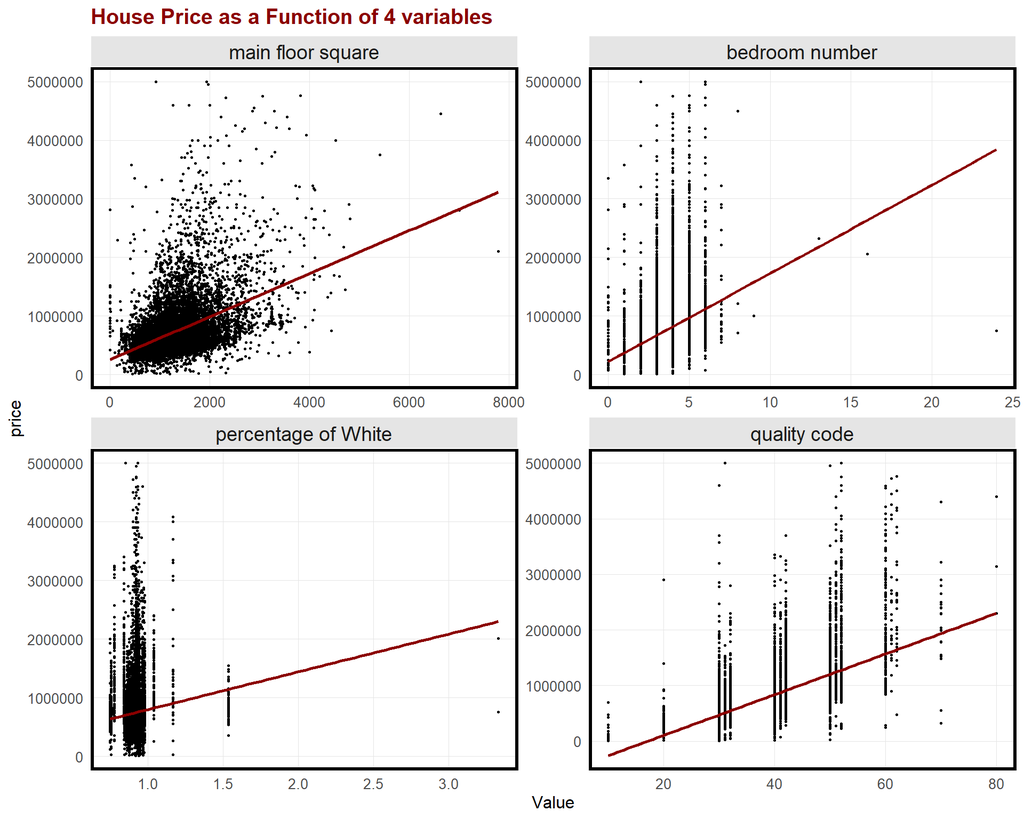

```r
features <- c('percentage of White','bedroom number','quality code','main floor square')
names(features)<-c('pctWhite','nbrBedRoom','qualityCode','mainfloorSF')

price.house.plot <-
  st_drop_geometry(train_data) %>%
  dplyr::select(price, pctWhite, nbrBedRoom,qualityCode,mainfloorSF) %>%
  filter(price <= 5000000) %>%
  gather(Variable, Value, -price) %>%
  ggplot(aes(Value, price)) +
  geom_point(size = .5) +
  geom_smooth(method = "lm", se=F, colour = "darkred") +
  facet_wrap(~Variable, ncol = 2, scales = "free",
             labeller = labeller(Variable = features)) +
  plotTheme() +
  labs(title = "House Price as a Function of 4 variables")
price.house.plot
```

### 2.3.6 Home price as a function of trasit stations

From scatter plot below, we take house price as a function of the average distance of five nearest transit stations. It shows that the longer distance the house to the transit station, the lower the house price is.

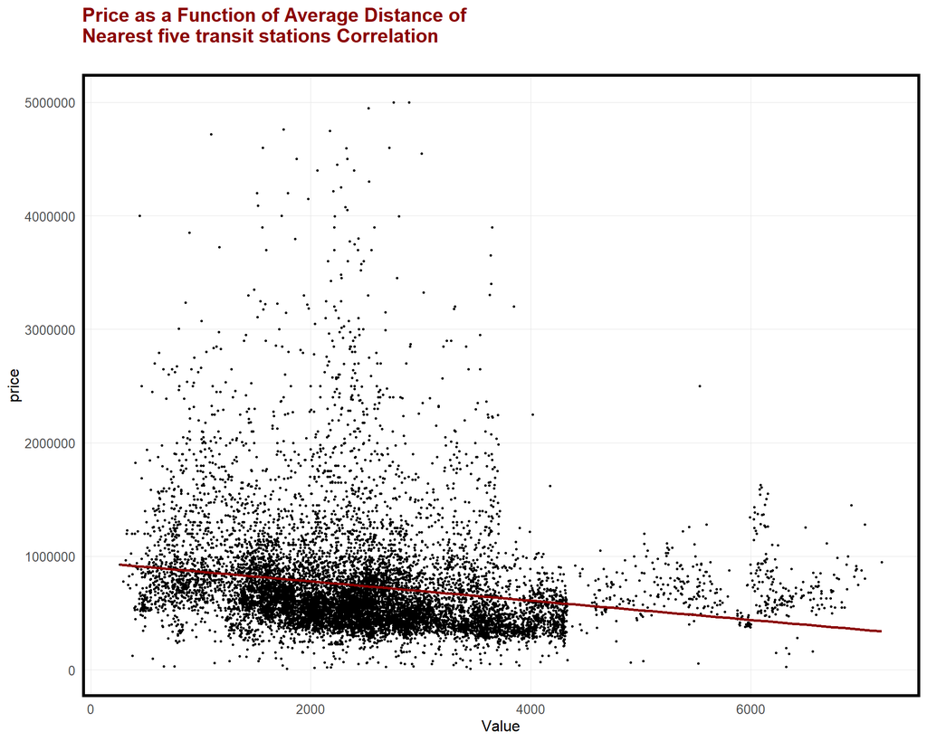

```r
price.tra_station.plot <-
  st_drop_geometry(train_data) %>%
  dplyr::select(price, Tra_station_nn5 ) %>%
  filter(price <= 5000000) %>%
  gather(Variable, Value, -price) %>%
  ggplot(aes(Value, price)) +
  geom_point(size = .5) +
  geom_smooth(method = "lm", se=F, colour = "darkred") +
  labs(title = "Price as a Function of Average Distance of\nNearest five transit stations Correlation\n") +
  plotTheme()
price.tra_station.plot
```

## 2.4 Map of variables

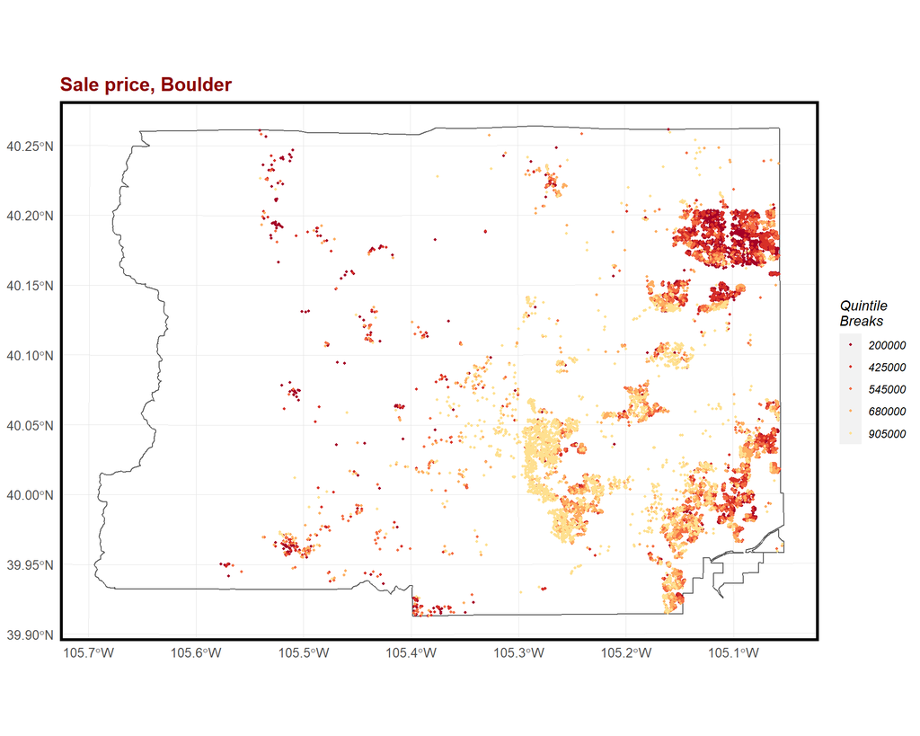

```r
ggplot() +
  geom_sf(data = boulder.boundary, fill = "transparent") +
  geom_sf(data = train_data, aes(colour = q5(price)),
          show.legend = "point", size = .75) +
  scale_colour_manual(values = palette,
                      labels=qBr(train_data,"price"),
                      name="Quintile\nBreaks") +
  labs(title="Sale price, Boulder") +
  mapTheme() +
  plotTheme()
```

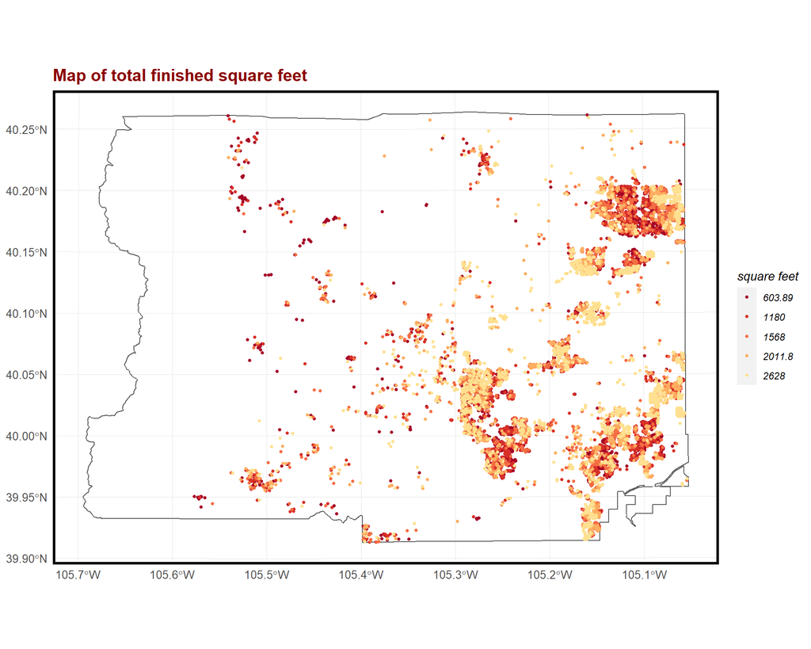

```r
ggplot() +
    geom_sf(data=boulder.boundary,fill="transparent") +
  geom_sf(data=train_data,aes(color = q5(TotalFinishedSF)),size = 1) +
  scale_color_manual(values =palette,
                     labels = qBr(train_data,'TotalFinishedSF'),
                     name = "square feet") +
  labs(title = 'Map of total finished square feet') +
  mapTheme() +
  plotTheme()
```

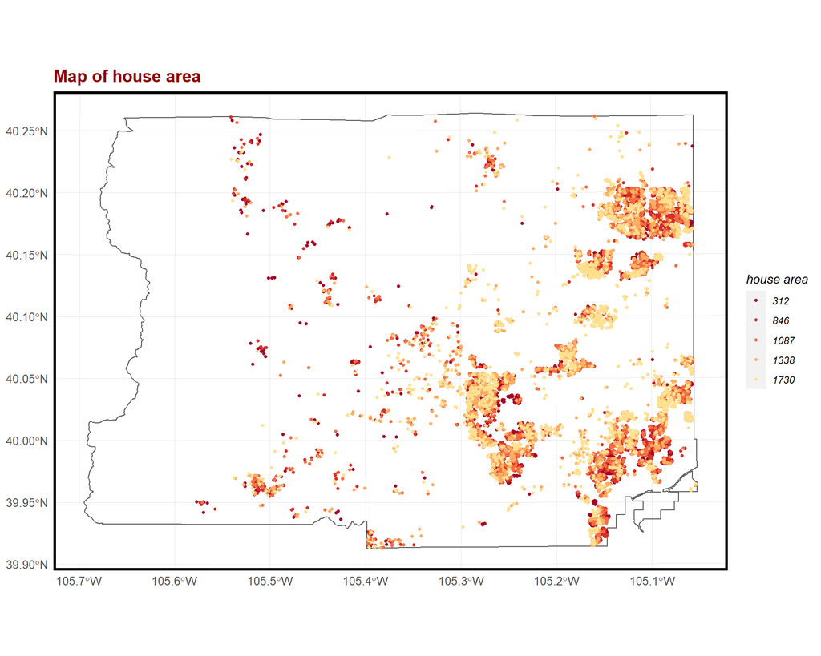

```r
ggplot() +
    geom_sf(data=boulder.boundary,fill="transparent") +
  geom_sf(data=train_data,aes(color = q5(mainfloorSF)),size = 1) +
  scale_color_manual(values =palette,labels = qBr(train_data,'mainfloorSF'),name = "house area") +labs(title = 'Map of house area') +
  mapTheme() +
  plotTheme()
```

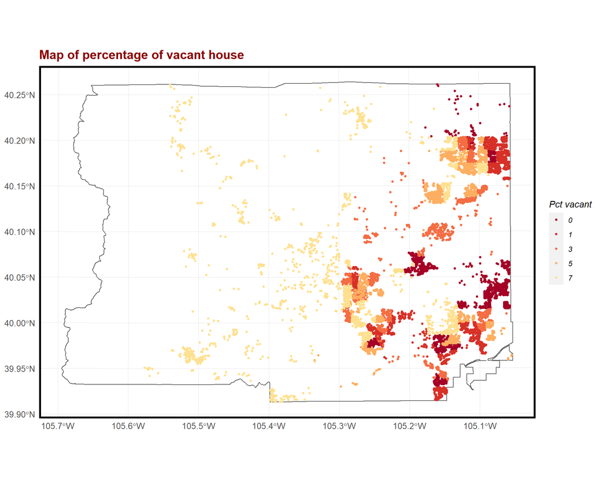

```r
ggplot() +
    geom_sf(data=boulder.boundary,fill="transparent") +
  geom_sf(data=train_data,aes(color = q5(pctTotalVacant)),size = 1) +
  scale_color_manual(values = palette,
                     labels = qBr(train_data,'pctTotalVacant'),
                     name = "Pct vacant")+
labs(title = 'Map of percentage of vacant house') +
  mapTheme() +
  plotTheme()
```

The map below show the average distance to five nearest restaurants. The darker the color is, the lower the distance is. In the center and north east and south east county, the distance is quite low, which means there are more restaurant around those districts, the amenity facility are more convenient.

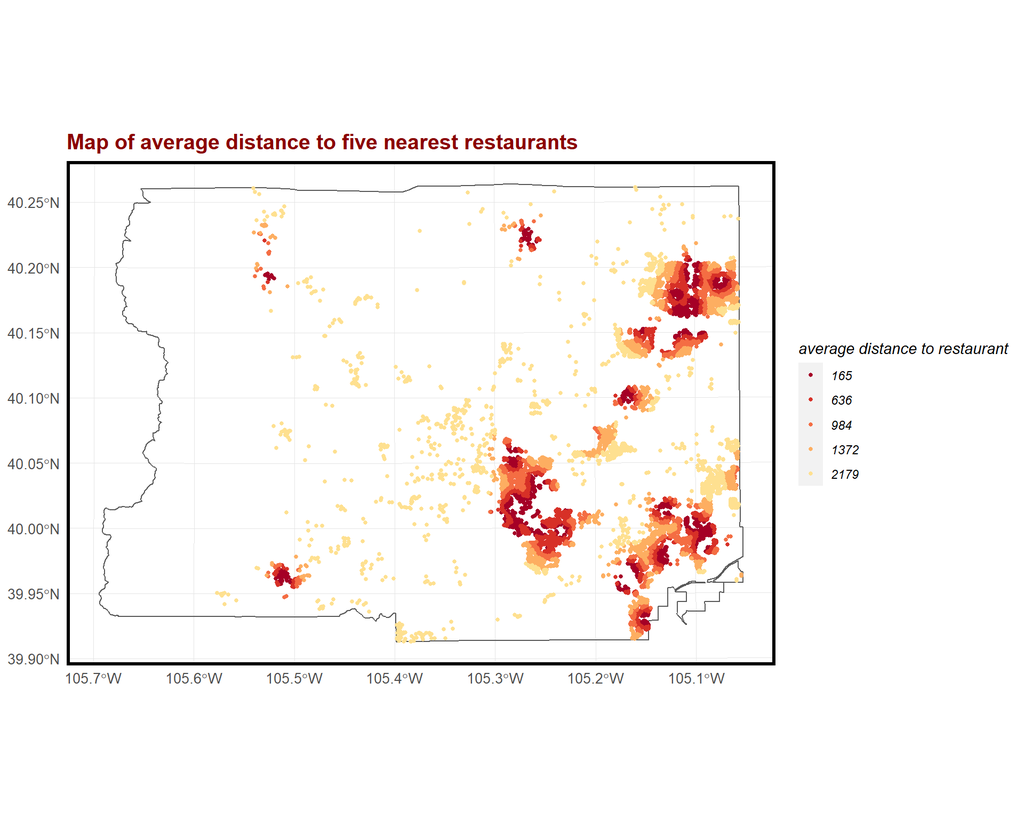

```r
ggplot() +
    geom_sf(data=boulder.boundary,fill="transparent") +
  geom_sf(data=train_data,aes(color = q5(restaurant_nn5)),size = 1) +
  scale_color_manual(values = palette,
                    labels = qBr(train_data,'restaurant_nn5'),
                     name = "average distance to restaurant")+
labs(title = 'Map of average distance to five nearest restaurants') +
  mapTheme() +
  plotTheme()
```

# **03. Methods**

Here, we adopt geospatial machine learning models to predict house price with the existing data as accurate and generalized as possible. We firstly build a ordinary least squares regression model with several features,them try to adjust selected features to optimization model. The main measurements we considered are residual standard error, $R^2$, mean absolute error(MAE), and p-value. MAE is calculated by taking the mean of the absolute values of subtracting each predicted housing prices from the corresponding given prices in the testing dataset. Residual standard is the error of the coefficient, which helps us understand how reliable the coefficient is. The p-value tells us whether the variable is a useful predictor, and $R^2$ is a percentage ‘goodness of fit’ indicator. In addtion, we use k-fold cross validation to see whether the model is generalized or not, whether the residual are spatial correlated or not.

# **04. Results**

## 4.1 Dataset Splitting and Model Building

The whole data is divided into training dataset and test dataset with the ratio of 3:1.

```r
# 1. Split dataset
set.seed(36)
# get index for training sample
inTrain <- caret::createDataPartition(
  y = (train_data$MUSA_ID),
  p = 0.75 , list = FALSE)

# split data into training and test
model_train <- train_data[inTrain,]
model_test<- train_data[-inTrain,]
```

```r
## Model 1 : only with internal features
M1 <- lm(price ~.,  data=st_drop_geometry(model_train)%>%
          select(price,designCode,
            qualityCode,EffectiveYear,nbrBedRoom,mainfloorSF,landmark_nn2,
 health_nn1, Tra_station_nn5, Openspace_nn5, Area_Trail_nn4,pctRenterOccupied,pctTotalVacant,pctWhite,pctPoverty,library_nn3 ))

M1.1 <- lm(price ~.,  data=st_drop_geometry(model_train)%>%
          select(price,designCode,
            qualityCode,EffectiveYear,nbrBedRoom,mainfloorSF,landmark_nn2,
 health_nn1, Tra_station_nn5, Openspace_nn5, Area_Trail_nn4,pctRenterOccupied,pctTotalVacant,pctWhite,pctPoverty,library_nn3,MedHHInc ))


M1.2<- lm(model_train$price ~.,  data=st_drop_geometry(model_train)%>%
          select(pctRenterOccupied,pctWhite,pctTotalVacant,MedHHInc,bsmtSF,carStorageSF,nbrThreeQtrBaths,qualityCode,EffectiveYear,nbrBedRoom,designCode,health_nn1,landmark_nn5,Openspace_nn5,Tra_station_nn2 ))


M2 <- lm(price ~.,  data=st_drop_geometry(model_train)%>%
          select(price,
            qualityCode,EffectiveYear,mainfloorSF,
 health_nn1,designCode,school_nn3,theater_nn2,
Tra_station_nn2, Openspace_nn5, MedHHInc,
nbrBedRoom,landmark_nn2,  restaurant_nn5,
 health_nn1, Tra_station_nn5, Openspace_nn5,
school_nn3,theater_nn2,TotalOccupied,restaurant_nn3,
Area_Trail_nn4,pctRenterOccupied,pctTotalVacant,pctWhite,pctPoverty,library_nn3))

M3 <- lm(price ~.,  data=st_drop_geometry(model_train)%>%
          select(price,TotalFinishedSF,
            qualityCode,EffectiveYear,nbrBedRoom,mainfloorSF,
 health_nn1,
Tra_station_nn5, Openspace_nn5, Area_Trail_nn4,pctTotalVacant,pctWhite,pctPoverty     ))

M4<- lm(price ~.,  data=st_drop_geometry(model_train)%>%
          select(price,
            qualityCode,EffectiveYear,nbrBedRoom,mainfloorSF,landmark_nn5,  health_nn5,
Tra_station_nn3, Openspace_nn5,pctTotalVacant,pctPoverty  ))

M5<- lm(price ~.,  data=st_drop_geometry(model_train)%>%
          select(price,
            qualityCode,designCode,EffectiveYear,nbrBedRoom,mainfloorSF,landmark_nn5,  health_nn5,
Tra_station_nn3, Openspace_nn5,pctTotalVacant,pctPoverty  ))
```

After comparasion, the final model we choose is Model 2, here is the summary of this model.

```r
stargazer(M2, type = "html",
          title = "Table 4.2 Summary Statistics of Model 2 ",
          header = FALSE,
          single.row = TRUE)
```

**Table 4.2 Summary Statistics of Model 2**

|  | *Dependent variable:* |
| --- | --- |
|  | price |
| qualityCode | 29,496.110*** (805.705) |
| EffectiveYear | -783.717*** (301.460) |
| mainfloorSF | 179.583*** (10.450) |
| health_nn1 | -5.507 (3.932) |
| designCode0020 | 117,067.700*** (11,762.100) |
| designCode0040 | 25,156.720 (25,635.660) |
| designCode0050 | 65,197.400*** (17,274.310) |
| designCode0120 | -43,645.260** (17,645.060) |
| school_nn3 | 0.647 (4.527) |
| theater_nn2 | 0.048 (1.586) |
| Tra_station_nn2 | -124.827*** (14.603) |
| Openspace_nn5 | 70.988*** (6.855) |
| MedHHInc | -0.245 (0.329) |
| nbrBedRoom | 16,979.710*** (4,808.465) |
| landmark_nn2 | -40.645*** (2.995) |
| restaurant_nn5 | -5.177 (28.050) |
| Tra_station_nn5 | 111.354*** (15.025) |
| TotalOccupied | -23.184*** (5.437) |
| restaurant_nn3 | -14.070 (29.002) |
| Area_Trail_nn4 | 53.178*** (10.068) |
| pctRenterOccupied | -150,271.500*** (29,562.780) |
| pctTotalVacant | 4,143.485*** (1,043.636) |
| pctWhite | -138,042.400** (62,523.550) |
| pctPoverty | 179,307.100** (88,381.030) |
| library_nn3 | -42.296*** (3.055) |
| Constant | 1,490,557.000** (589,962.500) |
| Observations | 8,448 |
| R<sup>2</sup> | 0.546 |
| Adjusted R<sup>2</sup> | 0.545 |
| Residual Std. Error | 373,185.000 (df = 8422) |
| F Statistic | 405.437*** (df = 25; 8422) |
| *Note:* | p<0.1; p<0.05; p<0.01 |

```r
training_model_final<-M2
```

## 4.2 Training set of summary results

```r
# 2. Table of model summary on my training set

broom::glance(training_model_final) %>%
  kable(caption = ' Summary of Model Evaluation Parameters') %>%
  kable_styling("striped",stripe_color = "gray!6" ,full_width = F)
```

Summary of Model Evaluation Parameters

| r.squared | adj.r.squared | sigma | statistic | p.value | df | logLik | AIC | BIC | deviance | df.residual | nobs |
| --- | --- | --- | --- | --- | --- | --- | --- | --- | --- | --- | --- |
| 0.5461776 | 0.5448304 | 373185 | 405.4368 | 0 | 25 | -120360.6 | 240775.1 | 240965.3 | 1172907325076101 | 8422 | 8448 |

```r
# 3. MAE, MAPE on test set

model_test2 <- model_test %>%
mutate(Regression = "Baseline Regression",
         SalePrice.Predict  = predict(M2, newdata = model_test),
         SalePrice.Error = price - SalePrice.Predict,
          SalePrice.AbsError = abs(price - SalePrice.Predict),
         SalePrice.APE  = abs(price - SalePrice.Predict) / price)%>%
  filter(price < 5000000)

generalization<-as.data.frame(cbind(mean(model_test2$SalePrice.AbsError,na.rm = T),
                                    mean(model_test2$SalePrice.APE,na.rm = T)))

colnames(generalization)<-c("Mean Absolute Errors (MAE)","MAPE")

kable(generalization,
      caption = ' MAE and MAPE for Test Dataset') %>%
  kable_styling("striped", stripe_color = "gray!6",full_width = F)
```

MAE and MAPE for Test Dataset

| Mean Absolute Errors (MAE) | MAPE |
| --- | --- |
| 194219.5 | 0.3088744 |

## 4.4 Cross validation

we conduct cross validation to evaluate the generalizability of the final model. We split the training set into 100 folders. Every time we use 1 folder as test data and the rest of 99 folds as training data. Within the Cross-validation Test Summary table, the R-square, RMSE, and MAE in each of 100 fold are presented. In order to better visualize those 100 results, we made histograms and scatter plot.

```r
##  use caret package cross-validation method

fitControl <- caret:: trainControl(method = "cv", number = 100,savePredictions = TRUE)
set.seed(233)

mode2.cv <-
caret::train(price ~ .,data = st_drop_geometry(train_data) %>%
                 dplyr::select(
        price,
            qualityCode,EffectiveYear,mainfloorSF,
 health_nn1,designCode,school_nn3,theater_nn2,
Tra_station_nn2, Openspace_nn5, MedHHInc,
nbrBedRoom,landmark_nn2,  restaurant_nn5,
 health_nn1, Tra_station_nn5, Openspace_nn5,
school_nn3,theater_nn2,TotalOccupied,restaurant_nn3,
Area_Trail_nn4,pctRenterOccupied,pctTotalVacant,pctWhite,pctPoverty,library_nn3) ,
 method = "lm", trControl = fitControl, na.action =  na.pass)

mode2.cv
```

```
## Linear Regression
##
## 11264 samples
##    22 predictor
##
## No pre-processing
## Resampling: Cross-Validated (100 fold)
## Summary of sample sizes: 11152, 11152, 11152, 11152, 11152, 11151, ...
## Resampling results:
##
##   RMSE      Rsquared   MAE
##   369290.8  0.5938779  207220.9
##
## Tuning parameter 'intercept' was held constant at a value of TRUE
```

```r
#mode2.cv$resample[1:5,]
#mean(mode2.cv$resample[,3]) #resample third column,MAE,mean absolute error.

## show RMSE, MAE, R^2
kable(mode2.cv$resample,
          caption = 'Cross validation Test Summary ') %>%
  kable_styling("striped", full_width = F)
```

Cross validation Test Summary

| RMSE | Rsquared | MAE | Resample |
| --- | --- | --- | --- |
| 313593.0 | 0.6503723 | 212784.5 | Fold001 |
| 195386.5 | 0.7248978 | 143049.4 | Fold002 |
| 264328.6 | 0.6867979 | 189219.1 | Fold003 |
| 339289.8 | 0.7243607 | 207197.3 | Fold004 |
| 283327.2 | 0.6483015 | 207078.8 | Fold005 |
| 412845.3 | 0.6606279 | 218493.6 | Fold006 |
| 330801.5 | 0.5129606 | 218973.7 | Fold007 |
| 259502.4 | 0.6223017 | 201957.3 | Fold008 |
| 219423.5 | 0.6924457 | 167781.3 | Fold009 |
| 225328.3 | 0.6796926 | 170661.7 | Fold010 |
| 419185.2 | 0.4914877 | 251073.3 | Fold011 |
| 415397.6 | 0.6610747 | 212249.1 | Fold012 |
| 283429.9 | 0.5486336 | 199214.7 | Fold013 |
| 278218.5 | 0.6058513 | 200194.4 | Fold014 |
| 228865.5 | 0.7110058 | 163082.5 | Fold015 |
| 2965583.6 | 0.0217374 | 503281.4 | Fold016 |
| 541903.2 | 0.4848768 | 252166.3 | Fold017 |
| 291145.8 | 0.6930585 | 194076.7 | Fold018 |
| 314517.0 | 0.6523394 | 207548.1 | Fold019 |
| 308585.8 | 0.6952240 | 186037.4 | Fold020 |
| 285452.1 | 0.6715779 | 216246.5 | Fold021 |
| 333185.7 | 0.5223987 | 213388.3 | Fold022 |
| 283011.0 | 0.6311137 | 188900.4 | Fold023 |
| 263605.9 | 0.6331214 | 179015.2 | Fold024 |
| 322145.6 | 0.5941220 | 198960.3 | Fold025 |
| 682135.7 | 0.1710752 | 234514.3 | Fold026 |
| 214698.5 | 0.6314766 | 163560.0 | Fold027 |
| 281963.0 | 0.5897557 | 199743.0 | Fold028 |
| 264315.3 | 0.6683262 | 167212.7 | Fold029 |
| 214294.2 | 0.7136424 | 164751.2 | Fold030 |

[output cut: 70 more lines]

```r
kable(mode2.cv$resample[1:5,],
      caption = 'Cross v Test Summary in first 5 output ') %>%
  kable_styling("striped", full_width = F)
```

Cross v Test Summary in first 5 output

| RMSE | Rsquared | MAE | Resample |
| --- | --- | --- | --- |
| 313593.0 | 0.6503723 | 212784.5 | Fold001 |
| 195386.5 | 0.7248978 | 143049.4 | Fold002 |
| 264328.6 | 0.6867979 | 189219.1 | Fold003 |
| 339289.8 | 0.7243607 | 207197.3 | Fold004 |
| 283327.2 | 0.6483015 | 207078.8 | Fold005 |

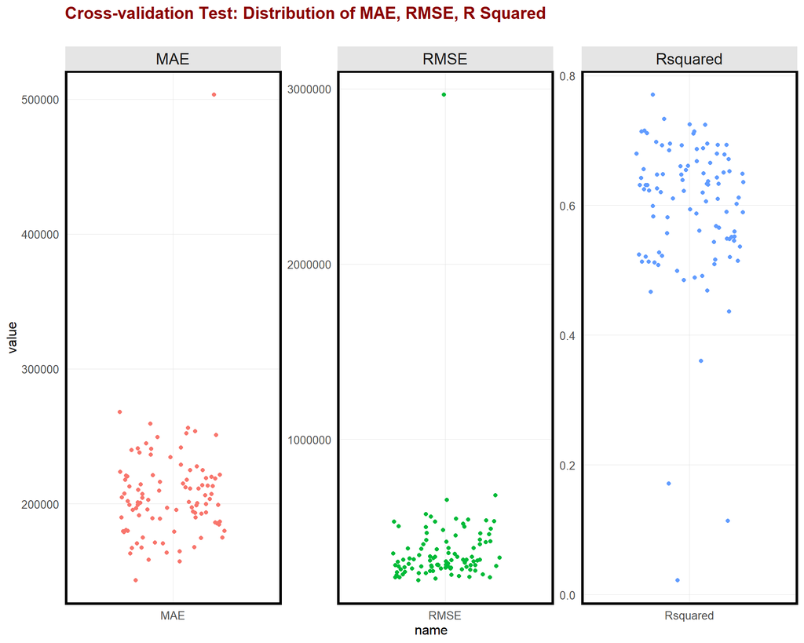

```r
mode2.cv$resample %>%
  pivot_longer(-Resample) %>%
  mutate(name = as.factor(name)) %>%
  ggplot(., aes(x = name, y = value, color = name)) +
  geom_jitter(width = 0.3) +
  facet_wrap(~name, ncol = 3, scales = "free") +
 theme_minimal(
  base_size = 11,
  base_family = "",
  base_line_size = 0.5,
  base_rect_size = 0.5
) +
  theme(legend.position = "none") +
  labs(title = 'Cross-validation Test: Distribution of MAE, RMSE, R Squared\n') +
  plotTheme()
```

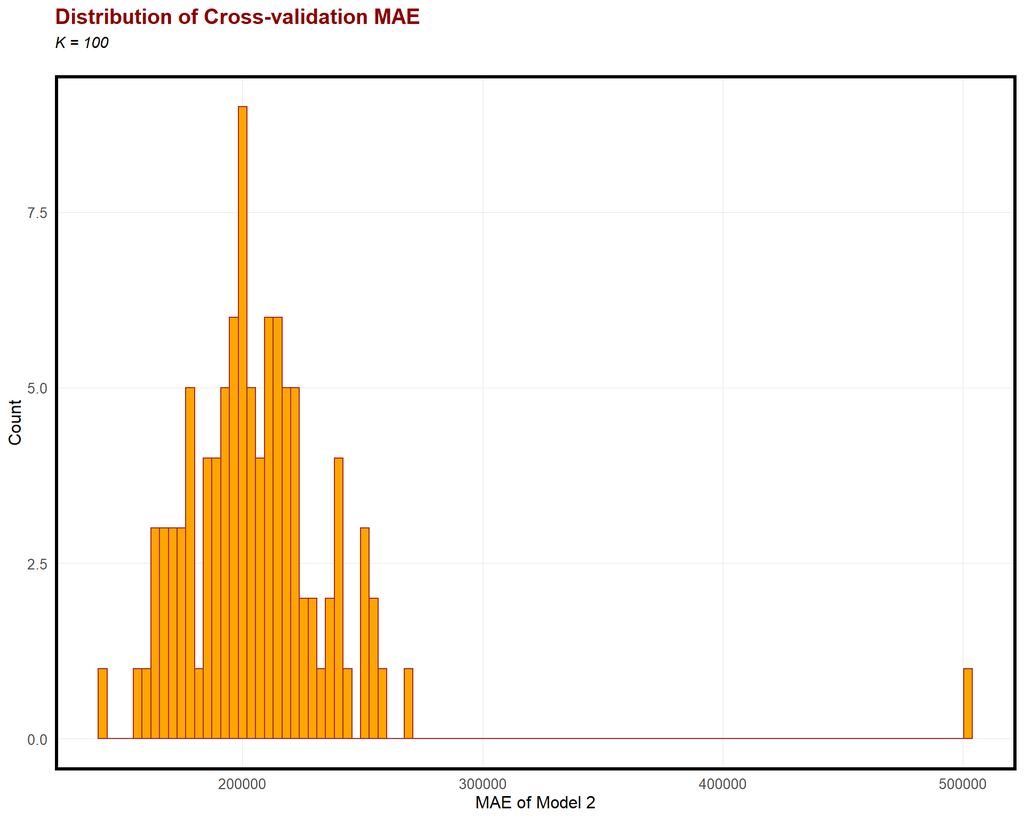

```r
ggplot(data = mode2.cv$resample) +
  geom_histogram(bins = 100,aes(x = mode2.cv$resample$MAE),color='brown' ,fill = 'orange') +
  labs(title="Distribution of Cross-validation MAE",
       subtitle = "K = 100\n") +
  xlab('MAE of Model 2') +
  ylab('Count') +
  plotTheme()
```